# Osburn-Kendra_Project1

Kendra Osburn

7/25/2019

# Part 1: HO2 data preparation and exploration

## Data preparation

#### WHAT WE’RE DOING:

Importing & examining our data

#### HOW WE’RE DOING IT:

1. Read in the data
2. Remove missing data
3. View our newly imported data
1. head() shows us our first few entries
2. str() shows the structure

```r
HO2 <- read.csv("data/nyhh02.csv", header = T, stringsAsFactors = F)
HO2 <- na.omit(HO2)
head(HO2)
```

```
##       DATE DHOILNYH
## 1 6/2/1986    0.402
## 2 6/3/1986    0.393
## 3 6/4/1986    0.378
## 4 6/5/1986    0.390
## 5 6/6/1986    0.385
## 6 6/9/1986    0.373
```

```r
str(HO2)
```

```
## 'data.frame':    7697 obs. of  2 variables:
##  $ DATE    : chr  "6/2/1986" "6/3/1986" "6/4/1986" "6/5/1986" ...
##  $ DHOILNYH: num  0.402 0.393 0.378 0.39 0.385 0.373 0.365 0.389 0.394 0.398 ...
```

## Question 1:

What is the nature of HO2 returns? We want to reflect the ups and downs of price movements, something of prime interest to management. First, we calculate percentage changes as log returns. Our interest is in the ups and downs. To look at that we use `if` and `else` statements to define a new column called `direction`. We will build a data frame to house this analysis.

### EDA PT1: Construct & Calculate

#### WHAT WE’RE DOING:

Constructing a data frame to help us answer our business questions

#### HOW WE’RE DOING IT:

1. Create “return” – a new vector to calculate and house the percentage change as log returns
2. Create “size” – a new vector taking the absolute value of return
3. Create “direction” – a new vector simply indicating “up”,“down” or “same” as another way to view volatility
4. Create “date” – a new vector containing the dates from our dataset
5. Create “price” – a new vector containing the price from out dataset
6. Put all of our new vectors into a data frame

```r
return <- as.numeric(diff(log(HO2$DHOILNYH))) * 100
size <- as.numeric(abs(return))
direction <- ifelse(return > 0, "up", ifelse(return < 0, "down", "same"))
date <- as.Date(HO2$DATE[-1], "%m/%d/%Y")
price <- as.numeric(HO2$DHOILNYH[-1])
HO2.df <- na.omit(data.frame(date = date, price = price, return = return, size = size, direction = direction))
str(HO2.df)
```

```
## 'data.frame':    7696 obs. of  5 variables:
##  $ date     : Date, format: "1986-06-03" "1986-06-04" ...
##  $ price    : num  0.393 0.378 0.39 0.385 0.373 0.365 0.389 0.394 0.398 0.379 ...
##  $ return   : num  -2.26 -3.89 3.13 -1.29 -3.17 ...
##  $ size     : num  2.26 3.89 3.13 1.29 3.17 ...
##  $ direction: Factor w/ 3 levels "down","same",..: 1 1 3 1 1 1 3 3 3 1 ...
```

### EDA PT2: Visualize

### WHAT WE’RE DOING:

Quickly visualizing the data with plots

#### HOW WE’RE DOING IT:

1. Load the ggplot2 visualization library
2. Play around with different x and y variables

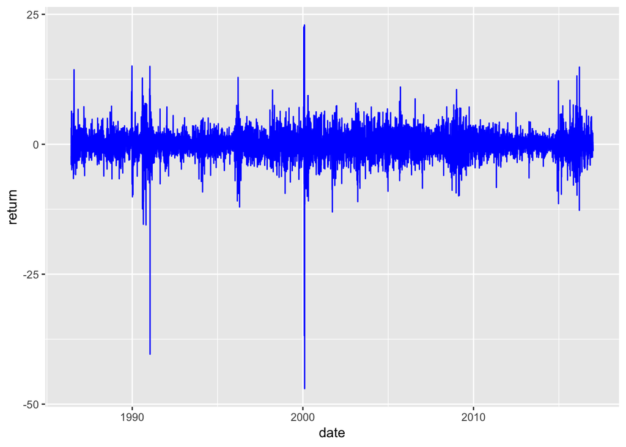

```r
library(ggplot2)
(p2_return <- ggplot(HO2.df, aes(x = date, y = return, group = 1)) + geom_line(colour = "blue"))
```

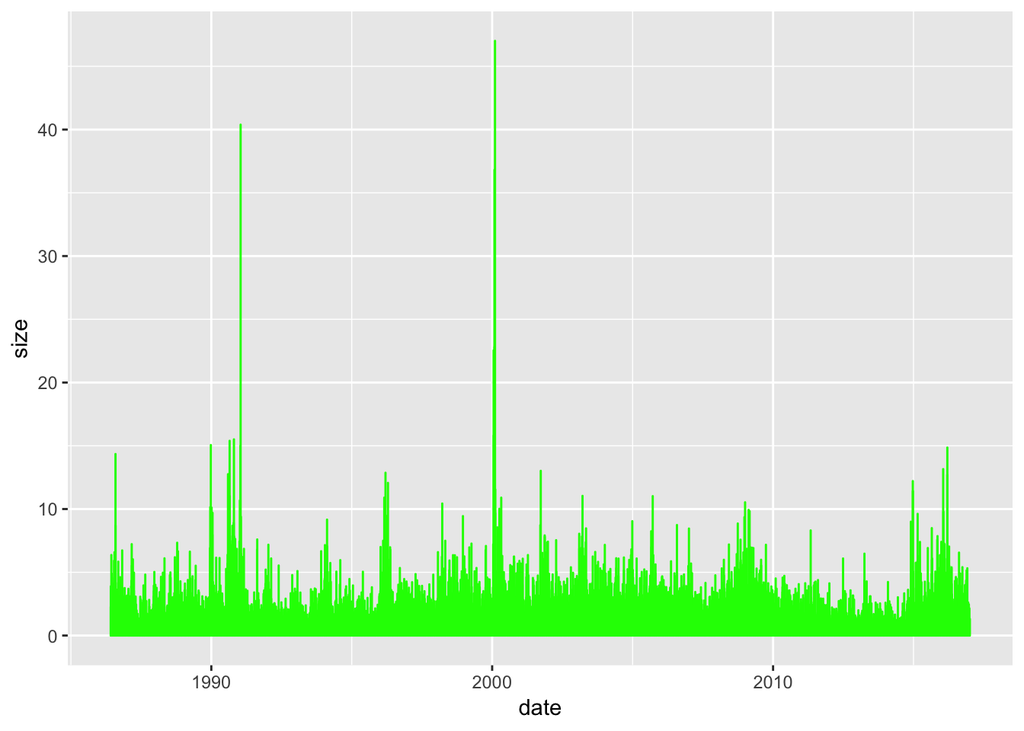

```r
(p3_size_green <- ggplot(HO2.df, aes(x = date, y = size, group = 1)) + geom_bar(stat = "identity", colour = "green"))
```

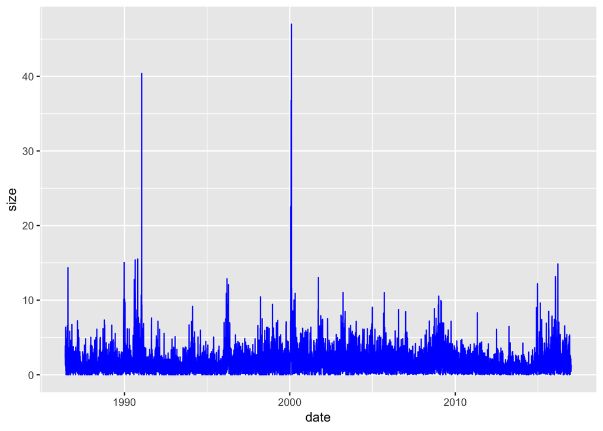

```r
# can be also written like this
(p3_size <- ggplot(HO2.df, aes(x = date, y = size, group = 1)) + geom_line(colour = "blue"))
```

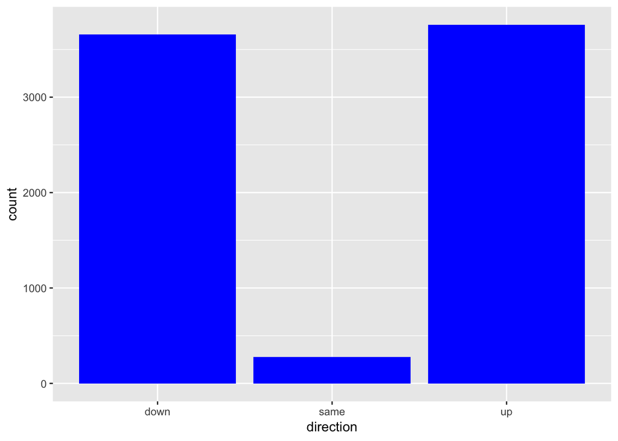

```r
(p4_direction <- ggplot(HO2.df, aes(x = direction)) + geom_bar(fill = "blue"))
```

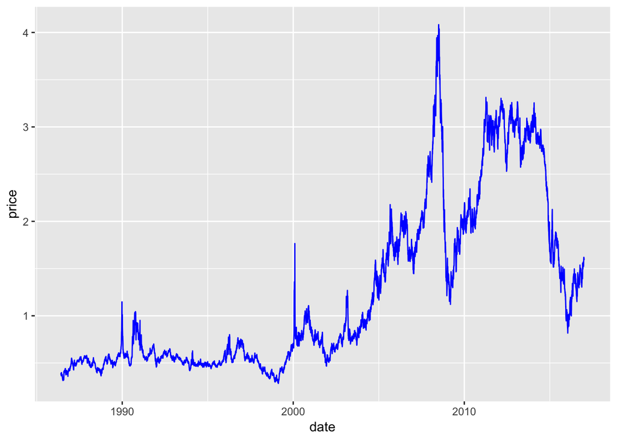

```r
(p1_price <- ggplot(HO2.df, aes(x = date, y = price, group = 1)) + geom_line(colour = "blue"))
```

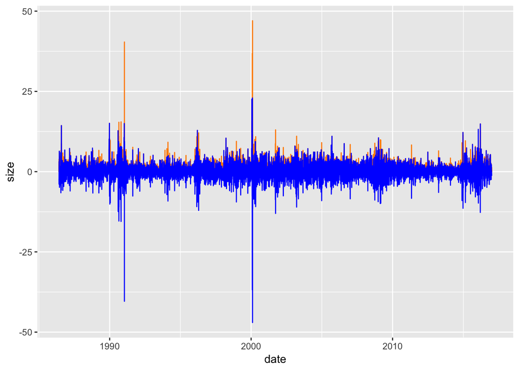

```r
(p <- ggplot(HO2.df, aes(date, size)) + geom_bar(stat = "identity", colour = "darkorange") + geom_line(data = HO2.df, aes(date, return), colour = "blue"))
```

### EDA PT3:

#### WHAT WE’RE DOING:

Deeper exploratory analysis